# SKILL ENHANCEMENT COURSE ANALYTICS / COMPUTING WITH PYTHON CLASS ASSIGNMENT

[figure not shown]

# Sudeep Kumar Singh

28021

Computer Science Hons.

Question 1. Explain the differences and similarities between Python and Excel. Provide real-life scenarios where Python is preferred over Excel and justify why.

# Python vs Excel: Differences, Similarities, and Use Cases

## Similarities

- **Data Analysis**: Both tools can analyze and manipulate data
- **Visualization**: Both can create charts and graphs
- **Calculations**: Both can perform complex calculations and data transformations
- **Automation**: Both support automation of repetitive tasks

## Key Differences

- **Programming vs Spreadsheet**: Python is a full programming language; Excel is primarily a spreadsheet tool
- **Scalability**: Python can handle much larger datasets (millions+ rows) than Excel (~1M row limit)
- **Reproducibility**: Python code is more reproducible and self-documenting than Excel formulas
- **Flexibility**: Python supports complex algorithms, machine learning, web scraping, etc.
- **Learning Curve**: Excel is generally easier to learn initially; Python requires programming knowledge

## When Python is Preferred (with Justifications)

1. **Big Data Processing**
   - *Scenario*: Analyzing customer behavior data for an e-commerce site (10M+ records)
   - *Justification*: Python libraries like pandas can handle data that would crash Excel, and distributed computing frameworks like Spark can process petabytes
2. **Complex Data Science**
   - *Scenario*: Predicting customer churn using machine learning
   - *Justification*: Python's scikit-learn, TensorFlow, and PyTorch enable sophisticated ML models that Excel cannot support
3. **Automated Reporting**
   - *Scenario*: Daily financial reports that pull from multiple databases
   - *Justification*: Python scripts can be scheduled, access multiple data sources, perform complex transformations, and generate reports automatically
4. **Web Scraping & API Integration**
   - *Scenario*: Collecting competitor pricing data from websites
   - *Justification*: Python's libraries (requests, BeautifulSoup) can extract web data and interact with APIs, which is impossible in Excel alone
5. **Version Control & Collaboration**
   - *Scenario*: Multiple data analysts working on the same analytical pipeline
   - *Justification*: Python code can be version-controlled with Git, enabling better collaboration and tracking changes

Question 2. Write a Python script that imports data from a CSV file, processes it using Pandas, and saves the filtered data to a new Excel file.

```python
import pandas as pd

# Import data from CSV file
try:
    df = pd.read_csv('data.csv')
except FileNotFoundError:
    print("Error: 'data.csv' not found. Please ensure the file exists in the correct directory.")

    data = {'Date': pd.to_datetime(['2023-01-01', '2023-01-02', None, '2023-01-04', '2023-01-05']),
            'Product': ['A', 'B', 'A', 'C', 'B'],
            'Region': ['North', 'South', 'North', 'West', 'East'],
            'Sales': [1200, 1600, 800, 1700, 1400],
            'Units': [50, 70, None, 80, 60]}
    df = pd.DataFrame(data)
    print("\nUsing sample data as 'data.csv' was not found:")


# Display the first few rows to understand the data
print("Original data:")
print(df.head())

# Process the data
# 1. Drop any rows with missing values
df_cleaned = df.dropna()

# 2. Filter data (example: keep only rows where 'Sales' > 1500)
df_filtered = df_cleaned[df_cleaned['Sales'] > 1500].copy()

# 3. Perform calculations (example: create a new column 'Doubled_Value')
df_filtered.loc[:, 'Doubled_Value'] = df_filtered['Sales'] * 2

# Display summary statistics
print("\nSummary of processed data:")
print(df_filtered.describe())
print(f"\nShape of original data: {df.shape}")
print(f"Shape of processed data: {df_filtered.shape}")

# Save the processed data to an Excel file
output_file = 'processed_data.xlsx'
df_filtered.to_excel(output_file, index=False)
print(f"\nProcessed data saved to {output_file}")
```

```
Original data:
         Date   Product Region  Sales  Units
0  2023-01-01  Widget C   East   1363     76
1  2023-01-02  Widget D  South   1242     28
2  2023-01-03  Widget A  South   1764     29
3  2023-01-04  Widget C   West   1063     80
4  2023-01-05  Widget C  South   1520     61

Summary of processed data:
             Sales      Units  Doubled_Value
count    46.000000  46.000000      46.000000
mean   1782.086957  49.152174    3564.173913
std     136.433431  22.639167     272.866862
min    1512.000000  12.000000    3024.000000
25%    1685.750000  30.250000    3371.500000
50%    1774.000000  45.500000    3548.000000
75%    1899.250000  62.500000    3798.500000
max    1996.000000  98.000000    3992.000000

Shape of original data: (100, 5)
Shape of processed data: (46, 6)

Processed data saved to processed_data.xlsx
```

Question 3. Describe the process of installing Anaconda and launching Jupyter Notebook. Explain how to create, save, and run Python code using Jupyter Notebookary.

## Installing Anaconda and Launching Jupyter Notebook

**Step 1: Download Anaconda**

- Visit the official [Anaconda website](https://www.anaconda.com/products/distribution) and choose the installer for your operating system.
- Click "Download" and save the installer.

**Step 2: Install Anaconda**

- Run the installer file.
- On Windows, select "Add Anaconda to my PATH "and "Register Anaconda as my default Python."
- On macOS and Linux, follow the default settings.

**Step 3: Verify Installation**

- Open a terminal or command prompt.
- Type:

  ```
  conda --version
  ```

  You should see the Anaconda version number.

**Step 4: Launch Jupyter Notebook**

- In a terminal or command prompt, type:

  ```
  jupyter notebook
  ```

- Your browser will open the Jupyter Notebook dashboard.

**Step 5: Create, Save, and Run Python Code**

1. In the Jupyter dashboard, click "New" -> "Python 3" to create a new notebook.
2. Type your Python code in a cell, then press Shift + Enter to run it.
3. Save your notebook by clicking the "Save" icon or pressing Ctrl + S (Cmd + S on macOS).
4. Click the notebook name at the top to rename it.

### Example: Simple Python Code

```
# Print a custom message
print("Hello, Universe!")

# Perform basic arithmetic
x = 15
y = 25
total = x + y
print("Sum of x and y is:", total)

# Loop example
for i in range(3):
        print("This is loop iteration:", i)

# Function example
def greet(name):
        return f"Greetings, {name}!"

print(greet("Jupyter"))
```

Question 3. Illustrate the differences between various Python data types (int, float, str, list, tuple, dict, etc.) with examples. Discuss the importance of understanding data types while handling large datasets.

Question 4. Define and explain conditional statements in Python with multiple use-case examples. Include examples of nested if-else and practical scenarios where nested conditions are necessary.

```python
# Illustrating differences between common Python data types

# Integer (int)
a = 10
print(f"Type of a ({a}):", type(a))

# Float (float)
b = 3.14
print(f"Type of b ({b}):", type(b))

# String (str)
c = "Hello, World!"
print(f"Type of c ('{c}'):", type(c))

# List (list): Mutable, ordered collection
d = [1, 2, 3, "apple", 4.5]
print(f"Type of d ({d}):", type(d))

# Tuple (tuple): Immutable, ordered collection
e = (1, 2, 3, "banana", 6.7)
print(f"Type of e ({e}):", type(e))

# Dictionary (dict): Key-value pairs, mutable, unordered (insertion order preserved in Python 3.7+)
f = {"name": "Alice", "age": 25, "city": "Delhi"}
print(f"Type of f ({f}):", type(f))

# Set (set): Unordered, unique elements
g = {1, 2, 3, 2, 1}
print(f"Type of g ({g}):", type(g))

print("\n--- Data Type Differences ---")
print("""
- int: Whole numbers, used for counting, indexing, etc.
- float: Numbers with decimals, used for measurements, calculations.
- str: Textual data, used for names, labels, etc.
- list: Ordered, mutable collection; can hold mixed types.
- tuple: Ordered, immutable collection; often used for fixed data.
- dict: Key-value mapping; fast lookup, flexible structure.
- set: Unordered, unique elements; useful for membership tests.
""")

print("--- Importance of Data Types in Large Datasets ---")
print("""
- Correct data types save memory and improve performance (e.g., using int8 instead of int64 for small numbers).
- Ensures accurate computations (e.g., float division vs integer division).
- Prevents errors (e.g., cannot sum strings and numbers).
- Enables efficient filtering, grouping, and aggregation in pandas DataFrames.
- Data type mismatches can cause bugs, slowdowns, or incorrect results in analysis and machine learning.
""")

# --- Conditional Statements in Python ---

print("\n--- Conditional Statements in Python ---")

# Basic if-else
x = 15
if x > 10:
    print(f"{x} is greater than 10")
else:
    print(f"{x} is not greater than 10")

# if-elif-else
score = 82
if score >= 90:
    grade = 'A'
elif score >= 75:
    grade = 'B'
elif score >= 60:
    grade = 'C'
else:
    grade = 'D'
print(f"Score: {score}, Grade: {grade}")

# Nested if-else (practical scenario: eligibility check)
age = 20
has_id = True
if age >= 18:
    if has_id:
        print("Eligible to vote.")
    else:
        print("Not eligible: ID required.")
else:
    print("Not eligible: Underage.")

# Real-world nested condition: Loan approval
income = 50000
credit_score = 720
if income > 40000:
    if credit_score > 700:
        print("Loan Approved")
    else:
        print("Loan Denied: Low credit score")
else:
    print("Loan Denied: Low income")

print("""
--- Explanation ---
- 'if' checks a condition; 'elif' checks additional conditions if previous ones are False; 'else' runs if none are True.
- Nested if-else is used when decisions depend on multiple, hierarchical conditions (e.g., eligibility, multi-step validation).
- In data analysis, conditional logic is used for filtering, categorizing, and handling missing or special values.
""")
```

```
Type of a (10): <class 'int'>
Type of b (3.14): <class 'float'>
Type of c ('Hello, World!'): <class 'str'>
Type of d ([1, 2, 3, 'apple', 4.5]): <class 'list'>
Type of e ((1, 2, 3, 'banana', 6.7)): <class 'tuple'>
Type of f ({'name': 'Alice', 'age': 25, 'city': 'Delhi'}): <class 'dict'>
Type of g ({1, 2, 3}): <class 'set'>

--- Data Type Differences ---

- int: Whole numbers, used for counting, indexing, etc.
- float: Numbers with decimals, used for measurements, calculations.
- str: Textual data, used for names, labels, etc.
- list: Ordered, mutable collection; can hold mixed types.
- tuple: Ordered, immutable collection; often used for fixed data.
- dict: Key-value mapping; fast lookup, flexible structure.
- set: Unordered, unique elements; useful for membership tests.

--- Importance of Data Types in Large Datasets ---

- Correct data types save memory and improve performance (e.g., using int8 instead of int64 for small numbers).
- Ensures accurate computations (e.g., float division vs integer division).
- Prevents errors (e.g., cannot sum strings and numbers).
- Enables efficient filtering, grouping, and aggregation in pandas DataFrames.
- Data type mismatches can cause bugs, slowdowns, or incorrect results in analysis and machine learning.


--- Conditional Statements in Python ---
15 is greater than 10
Score: 82, Grade: B
Eligible to vote.
Loan Approved

--- Explanation ---
- 'if' checks a condition; 'elif' checks additional conditions if previous ones are False; 'else' runs if none are True.
- Nested if-else is used when decisions depend on multiple, hierarchical conditions (e.g., eligibility, multi-step validation).
- In data analysis, conditional logic is used for filtering, categorizing, and handling missing or special values.
```

# SECTION 2

Question 1. Write a Python script that reads data from an Excel file, performs data cleaning (removes duplicates and fills missing values), and outputs a summary of the dat.

```python
# Create sample Indian data (including salary) and save it to an Excel file
df_sample = pd.DataFrame({
    'Name': ['Karthik', 'Ananya', 'Meena', 'Meena', 'Karthik'],
    'Age': [30, 24, None, 24, 30],
    'Salary': [50000, 60000, 45000, 45000, 50000],
    'City': ['Bengaluru', 'Mumbai', 'Delhi', 'Delhi', 'Bengaluru']
})
df_sample.to_excel("indian_data.xlsx", index=False)

# Read data from the Excel file
df_read = pd.read_excel("indian_data.xlsx")

# Remove duplicates and create a copy to avoid SettingWithCopyWarning
df_cleaned_data = df_read.drop_duplicates().copy()

# Convert 'Age' to string (object) before filling with non-numeric value
df_cleaned_data['Age'] = df_cleaned_data['Age'].astype(str).replace({'nan': 'Unknown'})

# Output summary
print(df_cleaned_data.info())
print(df_cleaned_data.describe(include='all'))
```

```
<class 'pandas.core.frame.DataFrame'>
Index: 4 entries, 0 to 3
Data columns (total 4 columns):
 #   Column  Non-Null Count  Dtype
---  ------  --------------  -----
 0   Name    4 non-null      object
 1   Age     4 non-null      object
 2   Salary  4 non-null      int64
 3   City    4 non-null      object
dtypes: int64(1), object(3)
memory usage: 160.0+ bytes
None
         Name   Age        Salary   City
count       4     4      4.000000      4
unique      3     3           NaN      3
top     Meena  24.0           NaN  Delhi
freq        2     2           NaN      2
mean      NaN   NaN  50000.000000    NaN
std       NaN   NaN   7071.067812    NaN
min       NaN   NaN  45000.000000    NaN
25%       NaN   NaN  45000.000000    NaN
50%       NaN   NaN  47500.000000    NaN
75%       NaN   NaN  52500.000000    NaN
max       NaN   NaN  60000.000000    NaN
```

Question 2. Demonstrate how to create various types of visualizations (line plots, bar charts, scatter plots, and histograms) using Matplotlib. Customize the visualizations with labels, legends, and colors .

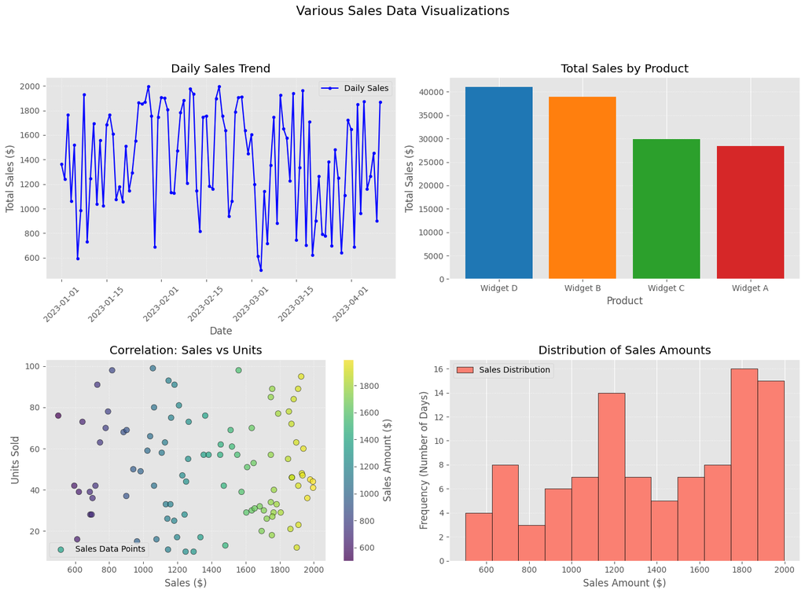

```python
import matplotlib.pyplot as plt
import pandas as pd

df_sorted = df.sort_values('Date')

fig, axes = plt.subplots(nrows=2, ncols=2, figsize=(14, 10))
fig.suptitle('Various Sales Data Visualizations', fontsize=16, y=1.02)

# --- Plot 1: Line Plot (Top-Left) ---
# Visualize sales trend over time
axes[0, 0].plot(df_sorted['Date'], df_sorted['Sales'], label='Daily Sales', color='blue', marker='.', linestyle='-')
axes[0, 0].set_title('Daily Sales Trend')
axes[0, 0].set_xlabel('Date')
axes[0, 0].set_ylabel('Total Sales ($)')
axes[0, 0].tick_params(axis='x', rotation=45)
axes[0, 0].legend()
axes[0, 0].grid(True, linestyle=':', alpha=0.7)

# --- Plot 2: Bar Chart (Top-Right) ---
# Visualize total sales per product
product_sales = df.groupby('Product')['Sales'].sum().sort_values(ascending=False)
colors_bar = ['#1f77b4', '#ff7f0e', '#2ca02c', '#d62728'] # Example colors
axes[0, 1].bar(product_sales.index, product_sales.values, color=colors_bar, label=product_sales.index)
axes[0, 1].set_title('Total Sales by Product')
axes[0, 1].set_xlabel('Product')
axes[0, 1].set_ylabel('Total Sales ($)')
# axes[0, 1].legend(title='Products') # Legend might be redundant if x-axis labels are clear
axes[0, 1].grid(axis='y', linestyle=':', alpha=0.7)

# --- Plot 3: Scatter Plot (Bottom-Left) ---
# Visualize relationship between Sales and Units sold
scatter = axes[1, 0].scatter(df['Sales'], df['Units'], c=df['Sales'], cmap='viridis', alpha=0.7, edgecolors='k', s=50, label='Sales Data Points')
axes[1, 0].set_title('Correlation: Sales vs Units')
axes[1, 0].set_xlabel('Sales ($)')
axes[1, 0].set_ylabel('Units Sold')
fig.colorbar(scatter, ax=axes[1, 0], label='Sales Amount ($)')
axes[1, 0].grid(True, linestyle=':', alpha=0.7)
axes[1, 0].legend()

# --- Plot 4: Histogram (Bottom-Right) ---
# Visualize the distribution of Sales values
axes[1, 1].hist(df['Sales'], bins=12, color='salmon', edgecolor='black', label='Sales Distribution')
axes[1, 1].set_title('Distribution of Sales Amounts')
axes[1, 1].set_xlabel('Sales Amount ($)')
axes[1, 1].set_ylabel('Frequency (Number of Days)')
axes[1, 1].legend()
axes[1, 1].grid(axis='y', linestyle=':', alpha=0.7)

plt.tight_layout(rect=[0, 0, 1, 0.97])

# Display the plots
plt.show()
```

Question 3. Write a Python program that generates a heatmap of correlation between different variables in a given dataset using Seaborn. Explain how to interpret the heatmp..

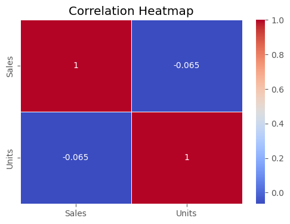

```python
import seaborn as sns

import matplotlib.pyplot as plt

corr_matrix = df[['Sales', 'Units']].corr()

# Create a heatmap using Seaborn
plt.figure(figsize=(6, 4))
sns.heatmap(corr_matrix, annot=True, cmap='coolwarm', linewidths=0.5)
plt.title("Correlation Heatmap")
plt.show()

# Interpretation:
# - Each cell shows how strongly two variables are correlated (closer to 1 or -1 means higher correlation).
# - Positive values (red) indicate that when one variable increases, the other also tends to increase.
# - Negative values (blue) indicate an inverse relationship.
# - Values near 0 suggest little to no linear correlation between the variables.
```

# SECTION 3

Question 1. Describe the key steps involved in building a Machine Learning model using Scikit-learn. Explain how to split data into training and testing sets and evaluate the model. t.

from sklearn.model_selection import train_test_split

## Building a Machine Learning Model with Scikit-learn

Building a machine learning model using the Scikit-learn library typically involves the following key steps:

1. **Import Libraries**: Load necessary modules from Scikit-learn (e.g., `model_selection`, specific estimators like `LinearRegression` or `LogisticRegression`, `metrics`) and data manipulation libraries like Pandas.
2. **Load and Prepare Data**:
   - Load the dataset, often into a Pandas DataFrame.
   - Perform **data cleaning**: Handle missing values (imputation or removal), correct errors, and deal with outliers.
   - **Feature Engineering**: Create new features from existing ones if needed.
   - **Feature Encoding**: Convert categorical features into numerical representations (e.g., One-Hot Encoding, Label Encoding).
   - **Feature Scaling**: Standardize or normalize numerical features, especially for algorithms sensitive to feature scales (e.g., SVM, KNN, Linear Regression with regularization).
3. **Select Features and Target**: Define which columns are the input features (X) and which column is the target variable (y) to predict.
4. **Split Data into Training and Testing Sets**:
   - This is crucial to evaluate the model's performance on unseen data.
   - Use `sklearn.model_selection.train_test_split`.
   - Typically, 70-80% of the data is used for training (`X_train`, `y_train`) and the remaining 20-30% for testing (`X_test`, `y_test`).
   - Setting a `random_state` ensures the split is the same each time the code runs, making results reproducible.

   ```
   # Example using train_test_split
   # Assuming X contains features and y contains the target variable
   # X_train, X_test, y_train, y_test = train_test_split(X, y, test_size=0.3, random_state=42)
   ```

5. **Choose and Instantiate a Model**: Select an appropriate algorithm based on the problem type (regression, classification) and data characteristics. Instantiate the model class.

   ```
   # Example for Linear Regression
   # from sklearn.linear_model import LinearRegression
   # model = LinearRegression()

   # Example for Logistic Regression (Classification)
   # from sklearn.linear_model import LogisticRegression
   # model = LogisticRegression()
   ```

6. **Train the Model**: Fit the model to the training data. The model learns the relationship between `X_train` and `y_train`.

   ```
   # model.fit(X_train, y_train)
   ```

7. **Make Predictions**: Use the trained model to make predictions on the test set (`X_test`).

   ```
   # y_pred = model.predict(X_test)
   ```

8. **Evaluate the Model**: Compare the predictions (`y_pred`) with the actual values (`y_test`) using appropriate evaluation metrics from `sklearn.metrics`.
   - **Regression Metrics**: Mean Absolute Error (MAE), Mean Squared Error (MSE), R-squared (R²).
   - **Classification Metrics**: Accuracy, Precision, Recall, F1-score, Confusion Matrix, ROC AUC score.

   ```
   # Example for Regression Evaluation
   # from sklearn.metrics import mean_squared_error, r2_score
   # mse = mean_squared_error(y_test, y_pred)
   # r2 = r2_score(y_test, y_pred)
   # print(f"MSE: {mse}, R-squared: {r2}")

   # Example for Classification Evaluation
   # from sklearn.metrics import accuracy_score, classification_report
   # accuracy = accuracy_score(y_test, y_pred)
   # report = classification_report(y_test, y_pred)
   # print(f"Accuracy: {accuracy}\nClassification Report:\n{report}")
   ```

9. **Tune Hyperparameters (Optional)**: Optimize model performance by tuning its hyperparameters using techniques like `GridSearchCV` or `RandomizedSearchCV`.
10. **Finalize Model**: Once satisfied with the performance, the model can be saved or deployed.

```python
from sklearn.datasets import load_iris
from sklearn.model_selection import train_test_split
from sklearn.linear_model import LogisticRegression
from sklearn.metrics import accuracy_score, classification_report

# Load iris dataset
iris = load_iris()
X, y = iris.data, iris.target

# Split the dataset
X_train, X_test, y_train, y_test = train_test_split(X, y, test_size=0.3, random_state=42)

# Train a logistic regression model
model = LogisticRegression(max_iter=200)
model.fit(X_train, y_train)

# Evaluate
y_pred = model.predict(X_test)
accuracy = accuracy_score(y_test, y_pred)

report = classification_report(y_test, y_pred)

print(f"Accuracy: {accuracy}")
print("Classification Report:")
print(report)
```

```
Accuracy: 1.0
Classification Report:
              precision    recall  f1-score   support

           0       1.00      1.00      1.00        19
           1       1.00      1.00      1.00        13
           2       1.00      1.00      1.00        13

    accuracy                           1.00        45
   macro avg       1.00      1.00      1.00        45
weighted avg       1.00      1.00      1.00        45
```

Question 2. Demonstrate the implementation of a Linear Regression model using Scikit-learn to predict house prices based on a given dataset. Include evaluation of model performance using appropriate metrics.t.

```
Mean Squared Error: 0.5305677824766757
R-squared Score: 0.595770232606166
```

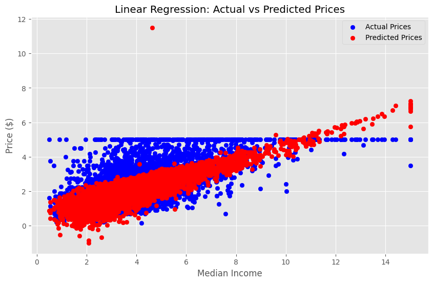

```python
from sklearn.datasets import fetch_california_housing
from sklearn.model_selection import train_test_split
from sklearn.linear_model import LinearRegression
from sklearn.metrics import mean_squared_error, r2_score
import matplotlib.pyplot as plt

# Load the California housing dataset
housing = fetch_california_housing()
X, y = housing.data, housing.target

# Split into training and test sets
X_train, X_test, y_train, y_test = train_test_split(
    X,
    y,
    test_size=0.3,
    random_state=42
)

# Initialize and train the model
lin_reg = LinearRegression()
lin_reg.fit(X_train, y_train)

# Predict
y_pred = lin_reg.predict(X_test)

# Evaluate
mse = mean_squared_error(y_test, y_pred)
r2 = r2_score(y_test, y_pred)
print("Mean Squared Error:", mse)
print("R-squared Score:", r2)

# Visualization: Actual vs Predicted (using the first feature of X_test)
plt.figure(figsize=(10, 6))
plt.scatter(X_test[:, 0], y_test, color='blue', label='Actual Prices')
plt.scatter(X_test[:, 0], y_pred, color='red', label='Predicted Prices')
plt.xlabel('Median Income')
plt.ylabel('Price ($)')
plt.title('Linear Regression: Actual vs Predicted Prices')
plt.legend()
plt.show()
```

Question 3. Write a Python script that builds a Logistic Regression model to classify email spam and evaluates its performance using accuracy, confusion matrix, and classification report..

```python
import pandas as pd
import numpy as np
from sklearn.model_selection import train_test_split
from sklearn.linear_model import LogisticRegression
from sklearn.metrics import accuracy_score, confusion_matrix, classification_report
from sklearn.feature_extraction.text import CountVectorizer


# Sample dataset
data = {
    'Email': [
        'FREE exclusive offer just for you',
        'Project status update',
        'URGENT: Your payment is due',
        'Notes from yesterday\'s meeting',
        'Buy luxury watches at 90% discount',
        'Team lunch on Friday',
        'You are the 1,000,000th visitor!',
        'Please review the proposal',
        'Your Netflix subscription expiring',
        'Request for vacation approval',
        'Hot singles in your area',
        'Weekly team progress report',
        'Make money fast from home',
        'Reminder: Client meeting tomorrow',
        'Enlarge your body parts now',
        'Quarterly financial summary',
        'Click here to claim your inheritance',
        'New security protocols update',
        'Lose 20 pounds in 2 weeks guaranteed',
        'Feedback on your presentation'
    ],
    'Spam': [ 1, 0, 1, 0, 1, 0, 1, 0, 1, 0, 1, 0, 1, 0, 1, 0, 1, 0, 1, 0]
}

# Create a DataFrame
df = pd.DataFrame(data)

# Split the data into features and target
X = df['Email']
y = df['Spam']

# Convert text data to numerical data using CountVectorizer
vectorizer = CountVectorizer()
X_vectorized = vectorizer.fit_transform(X)

# Split the data into training and testing sets
X_train, X_test, y_train, y_test = train_test_split(X_vectorized, y, test_size=0.3, random_state=42)

# Create a Logistic Regression model
model = LogisticRegression()

# Train the model
model.fit(X_train, y_train)

# Make predictions
y_pred = model.predict(X_test)

# Evaluate the model
accuracy = accuracy_score(y_test, y_pred)
conf_matrix = confusion_matrix(y_test, y_pred)
class_report = classification_report(y_test, y_pred)

print(f"Accuracy: {accuracy}")
print("Confusion Matrix:")
print(conf_matrix)
print("Classification Report:")
print(class_report)
```

```
Accuracy: 0.5
Confusion Matrix:
[[1 3]
 [0 2]]
Classification Report:
              precision    recall  f1-score   support

           0       1.00      0.25      0.40         4
           1       0.40      1.00      0.57         2

    accuracy                           0.50         6
   macro avg       0.70      0.62      0.49         6
weighted avg       0.80      0.50      0.46         6
```

Question 4. Explain the concept of Machine Learning (ML) and differentiate between supervised and unsupervised learning. Provide real-world examples of each type.

# Machine Learning: Concepts, Types, and Real-World Applications

## What is Machine Learning?

Machine Learning (ML) is a subset of artificial intelligence that enables systems to learn and improve from experience without being explicitly programmed. Instead of following static program instructions, ML algorithms build models based on sample data, known as "training data," to make predictions or decisions without being explicitly programmed to do so.

The key characteristic of ML is its ability to automatically identify patterns in data and use these patterns to make predictions on new, unseen data.

## Supervised Learning vs. Unsupervised Learning

### Supervised Learning

**Definition**: In supervised learning, the algorithm learns from labeled training data, meaning the input data comes with the correct output (or "answer"). The algorithm's task is to learn a mapping function from inputs to outputs.

**Process**:

1. The algorithm is trained on a dataset with known outcomes
2. It learns to predict the outcome given a set of inputs
3. The model's performance is evaluated based on how accurately it predicts the correct answers

**Key Characteristics**:

- Requires labeled data
- Goal is prediction
- Clear feedback on accuracy (model knows when it's wrong)
- Examples include classification and regression problems

**Real-World Examples**:

1. **Email Spam Classification**: Using features like sender information, subject line keywords, and content patterns to predict whether an email is spam or legitimate.
2. **Credit Scoring**: Predicting a customer's creditworthiness based on income, debt, payment history, and other financial attributes.
3. **Medical Diagnosis**: Predicting diseases from symptoms, lab tests, and medical images (e.g., detecting cancer in radiological images).
4. **House Price Prediction**: Estimating property values based on features like location, square footage, number of rooms, etc.
5. **Sentiment Analysis**: Determining whether text reviews or social media posts express positive, negative, or neutral sentiment.

### Unsupervised Learning

**Definition**: In unsupervised learning, the algorithm works with unlabeled data, discovering hidden patterns or intrinsic structures without guidance about correct outputs.

**Process**:

1. The algorithm is presented with data without predefined labels
2. It finds patterns, similarities, or differences in the data
3. Success is measured by the algorithm's ability to discover meaningful structures

**Key Characteristics**:

- Uses unlabeled data
- Goal is discovery of patterns
- No explicit right or wrong answers
- Examples include clustering, association, and dimensionality reduction

**Real-World Examples**:

1. **Customer Segmentation**: Grouping customers with similar purchasing behaviors without predefined categories, used in targeted marketing.
2. **Anomaly Detection**: Identifying unusual patterns in credit card transactions to flag potential fraud, without prior examples of what fraud looks like.
3. **Recommendation Systems**: Discovering groups of similar products or content that users might like based on their previous interactions.
4. **Topic Modeling**: Discovering abstract topics in a collection of documents, used in content organization and search optimization.
5. **Market Basket Analysis**: Finding combinations of products that are frequently purchased together, helping with store layout and promotions.

## Key Differences

| Aspect | Supervised Learning | Unsupervised Learning |
| --- | --- | --- |
| Data | Labeled | Unlabeled |
| Feedback | Direct | Indirect |
| Applications | Prediction, classification | Pattern discovery, grouping |
| Complexity | Generally simpler to understand | Often more complex to interpret |
| Examples | Regression, classification | Clustering, association rules |

Machine learning continues to evolve rapidly, with newer paradigms like semi-supervised learning (using both labeled and unlabeled data) and reinforcement learning (learning through trial and error with rewards) expanding the possibilities beyond the traditional supervised/unsupervised dichotomy.